# Lab7_chisq

Ilya Schurov, Olga Lyashevskaya, George Moroz, Alla Tambovtseva

2024-03-05

# Часть 1: Таблицы сопряженности, тест хи-квадрат и точный тест Фишера.

Формула критерия хи-квадрата (chi-squared test):
$$\chi^2 = \sum\limits_{i=1}^n\frac{(observed - expected)^2}{expected}$$

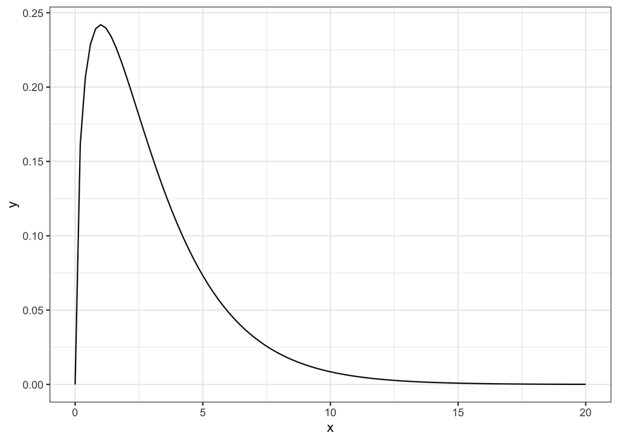

```r
library(ggplot2)

ggplot(data.frame(x = c(0, 20)), aes(x = x)) +
     stat_function(fun = dchisq, args = list(df = 3))
```

Распределение статистики хи-квадрат: [http://rstudio-pubs-static.s3.amazonaws.com/511113_1df8cae98e264fe3ae677db9fd51150f.html]

## Данные: Жадина-говядина

Жадина-говядина,

Солёный огурец,

На полу валяется,

Никто его не ест.

Жадина-говядина,

Турецкий барабан,

Кто на нём играет,

Тот рыжий таракан.

Жадина-говядина,

Пустая шоколадина.

Ответы участников закодировали по-английски так:  
*«солёный огурец»* ~ *pickle*, *«турецкий барабан»* ~ *Turkish drum*, *«шоколадина»* ~ *chocolate bar*

Переменные в датасете:

- `id`: идентификатор респондента (a numeric variable);
- `region`: регион проживания респондента (a factor variable);
- `fdistrict`: федеральный округ проживания респондента (a factor variable);
- `sex`: пол респондента (a factor variable, `F` for females, `M` for males);
- `phrase`: фраза, использованная респондентом для продолжения фразы (a factor variable, values: `солёный огурец`, `турецкий барабан`, `шоколадина`);
- `phrase.tr`: ее транслитерация с помощью пакета R `stringi` (a factor variable, values `solenyj ogurec`, `tureckij baraban`, `šokoladina`);
- `phrase.eng`: буквальный перевод на английский (a factor variable, values: `pickle`, `turkish drum`, `chocolate bar`).

```r
soc <- read_csv("https://raw.githubusercontent.com/olesar/2023dav4compling/main/data/socling.csv") %>%
  mutate_if(is.character, factor)
view(soc)
skimr::skim(soc)
```

Data summary

| Name | soc |
| --- | --- |
| Number of rows | 63 |
| Number of columns | 8 |
| _______________________ |  |
| Column type frequency: |  |
| factor | 6 |
| numeric | 2 |
| ________________________ |  |
| Group variables | None |

**Variable type: factor**

| skim_variable | n_missing | complete_rate | ordered | n_unique | top_counts |
| --- | --- | --- | --- | --- | --- |
| region | 0 | 1 | FALSE | 11 | Mos: 25, Oth: 22, Mos: 4, Res: 3 |
| fdistrict | 0 | 1 | FALSE | 7 | Cen: 29, Oth: 19, Far: 4, Vol: 4 |
| sex | 0 | 1 | FALSE | 2 | fem: 34, mal: 29 |
| phrase | 0 | 1 | FALSE | 3 | сол: 47, тур: 10, шок: 6 |
| phrase.tr | 0 | 1 | FALSE | 3 | sol: 47, tur: 10, šok: 6 |
| phrase.eng | 0 | 1 | FALSE | 3 | pic: 47, tur: 10, cho: 6 |

**Variable type: numeric**

| skim_variable | n_missing | complete_rate | mean | sd | p0 | p25 | p50 | p75 | p100 | hist |
| --- | --- | --- | --- | --- | --- | --- | --- | --- | --- | --- |
| X | 0 | 1 | 32.00 | 18.33 | 1 | 16.5 | 32 | 47.5 | 63 | ▇▇▇▇▇ |
| id | 0 | 1 | 5.16 | 2.74 | 1 | 3.0 | 5 | 8.0 | 10 | ▇▇▆▇▅ |

В датасете много регионов и федеральных регионов, поэтому для начала перекодируем таблицу, сфокусировавшись на противопоставлении *Moscow residents* vs *non-Moscow residents*.

```r
soc <- soc %>% mutate(moscow = factor(ifelse(region == "Moscow", "Moscow", "Not Moscow")))
summary(soc$moscow)
```

```
##     Moscow Not Moscow
##         25         38
```

**Переменные в центре внимания:** `phrase` и `moscow` (регион).

**Гипотеза исследования:**

Выбор фразы связан с местом проживания.

**Таблица сопряженности**

```r
soc.tabulated <- soc %>%
  select(phrase, moscow) %>%
  table()
soc.tabulated
```

```
##                   moscow
## phrase             Moscow Not Moscow
##   соленый огурец       16         31
##   турецкий барабан      9          1
##   шоколадина            0          6
```

Таблица пропорций для относительных частот:

```r
# a contingency table of proportions
prop.table(soc.tabulated)
```

```
##                   moscow
## phrase                 Moscow Not Moscow
##   соленый огурец   0.25396825 0.49206349
##   турецкий барабан 0.14285714 0.01587302
##   шоколадина       0.00000000 0.09523810
```

```r
# prop.table is a function of base R
# proportions(soc.tabulated) # do the same
```

то же в процентах:

```r
prop.table(soc.tabulated) * 100 # in %
```

```
##                   moscow
## phrase                Moscow Not Moscow
##   соленый огурец   25.396825  49.206349
##   турецкий барабан 14.285714   1.587302
##   шоколадина        0.000000   9.523810
```

**Статистические гипотезы:**

$H_0:$ Выбор фразы в генеральной совокупности не связан с местом проживания.

$H_1:$ Выбор фразы в генеральной совокупности связан с местом проживания.

или проще:

$H_0:$ Выбор фразы не связан с местом проживания.

$H_1:$ Выбор фразы связан с местом проживания.

Наши переменные категориальные (nominal, qualitative), поэтому используем критерий согласия хи-квадрат Пирсона.

### Тест хи-квадрат

```r
# Pearson's Chi-square test for independence
summary(soc.tabulated)
```

```
## Number of cases in table: 63
## Number of factors: 2
## Test for independence of all factors:
##  Chisq = 15.15, df = 2, p-value = 0.0005132
##  Chi-squared approximation may be incorrect
```

```r
soc.chisq <- chisq.test(soc.tabulated)
# chisq.test(soc.tabulated, correct = FALSE) # если нужно запретить применение Yates' continuity correction
soc.chisq
```

```
##
##  Pearson's Chi-squared test
##
## data:  soc.tabulated
## X-squared = 15.15, df = 2, p-value = 0.0005132
```

```r
# rstatix::chisq_test(soc.tabulated) # another option with anova-like output
```

**Статистическая интерпретация** p-value  
P-value меньше 0.05, а значит, при 5%-ом уровне значимости мы имеем основания отвергнуть нулевую гипотезу о независимости двух факторов.

**Содержательная интерпретация**  
Продолжение фразы в дразнилке “Жадина-говядина” зависит от региона проживания. Москвичи и не-москвичи используют разные версии продолжения дразнилки.

### Степени свободы (df)

для критерия хи-квадрат:

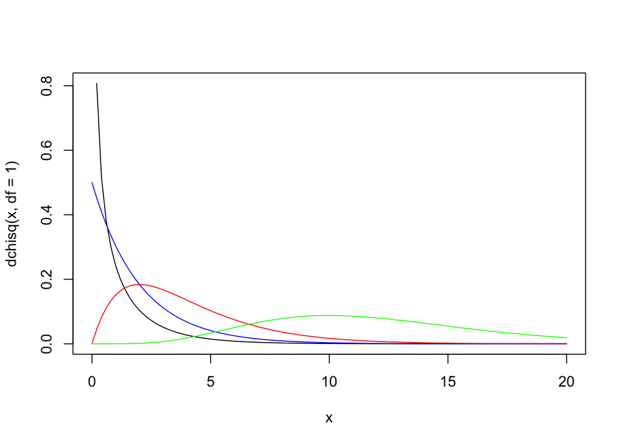

```r
curve(dchisq(x, df = 1), xlim = c(0, 20))
curve(dchisq(x, df = 2), xlim = c(0, 20), col = "blue", add = TRUE)
curve(dchisq(x, df = 4), xlim = c(0, 20), col = "red", add = TRUE)
curve(dchisq(x, df = 12), xlim = c(0, 20), col = "green", add = TRUE)
```

- Почему в нашем случае `df = 2`?

|  | Moscow | Not Moscow | Total |
| --- | --- | --- | --- |
| соленый огурец | ? | ? | 47 |
| турецкий барабан | ? | ? | 10 |
| шоколадина | ? | ? | 6 |
| Total | 25 | 38 | 63 |

|  | Moscow | Not Moscow | Total |
| --- | --- | --- | --- |
| соленый огурец | 16 | ? | 47 |
| турецкий барабан | ? | ? | 10 |
| шоколадина | ? | ? | 6 |
| Total | 25 | 38 | 63 |

Посчитаем:

|  | Moscow | Not Moscow | Total |
| --- | --- | --- | --- |
| соленый огурец | 16 | **47-16=31** | 47 |
| турецкий барабан | ? | ? | 10 |
| шоколадина | ? | ? | 6 |
| Total | 25 | 38 | 63 |

|  | Moscow | Not Moscow | Total |
| --- | --- | --- | --- |
| соленый огурец | 16 | **47-16=31** | 47 |
| турецкий барабан | 9 | **10-9=1** | 10 |
| шоколадина | **25-16-9=0** | **38-31-1=6** | 6 |
| Total | 25 | 38 | 63 |

Общее правило для вычисления `df`:

$$\text{df} = (r-1) \cdot (c-1),$$

### Допущения критерия хи-квадрат

- Исследуемые переменные являются категориальными
- Данные в таблице сопряженности представляют количество наблюдений (не проценты)
- **Ожидаемые** значения во всех ячейках (варианты: почти все, 80% ячеек) содержат более 5 наблюдений
- Каждое наблюдение вносит свой вклад только в одну группу (независимость)
- Группы независимы
- Выборка, предположительно, достаточно случайна

Вот гипотезы для теста:

H0: В популяции две категориальные переменные независимы. H1: В популяции две категориальные переменные зависимы.

**Ожидаемые значения**

```r
soc.chisq$observed
```

```
##                   moscow
## phrase             Moscow Not Moscow
##   соленый огурец       16         31
##   турецкий барабан      9          1
##   шоколадина            0          6
```

```r
soc.chisq$expected
```

```
##                   moscow
## phrase                Moscow Not Moscow
##   соленый огурец   18.650794  28.349206
##   турецкий барабан  3.968254   6.031746
##   шоколадина        2.380952   3.619048
```

```r
round(soc.chisq$expected,1)
```

```
##                   moscow
## phrase             Moscow Not Moscow
##   соленый огурец     18.7       28.3
##   турецкий барабан    4.0        6.0
##   шоколадина          2.4        3.6
```

Как видно, в половине ячеек ожидаемые значения менее 5, поэтому функция `chisq.test()` выдает предупреждение.

### Точный тест Фишера

Статистические гипотезы те же, нет требования на количество наблюдений.

```r
fisher.test(soc.tabulated)
```

```
##
##  Fisher's Exact Test for Count Data
##
## data:  soc.tabulated
## p-value = 0.0002995
## alternative hypothesis: two.sided
```

Точный тест Фишера показал, что вероятность получить таблицу сопряженности при данных фиксированных крайних средних строк и столбцов (маргинальных частотах или marginal means) c данными или более экстремальными зависимостями между строками и столбцами при предположении о независимости данных в строках и столбцах составляет 0.0002995.

**Статистическая интерпретация** p-value та же:  
P-value меньше 0.05, а значит, при 5%-ом уровне значимости мы имеем основания отвергнуть нулевую гипотезу о независимости двух факторов.

### Упражнение 1

Для начала объединим ответы респондентов “турецкий барабан” и “шоколадина” в один: добавим в данные столбец `pickle`.

```r
soc1 <- soc %>% mutate(pickle = factor(ifelse(phrase == "соленый огурец", "yes", "no")))
summary(soc1)
```

```
##        X              id                                region
##  Min.   : 1.0   Min.   : 1.000   Moscow                    :25
##  1st Qu.:16.5   1st Qu.: 3.000   Other                     :22
##  Median :32.0   Median : 5.000   Moskovskaja oblast        : 4
##  Mean   :32.0   Mean   : 5.159   Respublika Saha (Jakutija): 3
##  3rd Qu.:47.5   3rd Qu.: 8.000   Samarskaja oblast         : 2
##  Max.   :63.0   Max.   :10.000   Volgogradskaja oblast     : 2
##                                  (Other)                   : 5
##         fdistrict      sex                  phrase              phrase.tr
##  Abroad      : 2   female:34   соленый огурец  :47   šokoladina      : 6
##  Central     :29   male  :29   турецкий барабан:10   solenyj ogurec  :47
##  Far Eastern : 4               шоколадина      : 6   tureckij baraban:10
##  Northwestern: 2
##  Other       :19
##  Siberian    : 3
##  Volga       : 4
##          phrase.eng        moscow   pickle
##  chocolate bar: 6   Moscow    :25   no :16
##  pickle       :47   Not Moscow:38   yes:47
##  turkish drum :10
##
##
##
##
```

Исследуйте (не)зависимость выбора продолжения дразнилки от пола (переменная `sex`). Сформулируйте нулевую гипотезу и примените необходимый тест (не забывая проверить допущения!). Сформулируйте статистический вывод и содержательную интерпретацию.

```r
soc1.chisq <- soc1 %>%
  select(pickle, sex) %>%
  table() %>%
  chisq.test()
soc1.chisq
```

```
##
##  Pearson's Chi-squared test with Yates' continuity correction
##
## data:  .
## X-squared = 0.25237, df = 1, p-value = 0.6154
```

```r
soc1.chisq$expected
```

```
##       sex
## pickle    female      male
##    no   8.634921  7.365079
##    yes 25.365079 21.634921
```

### Данные: выбор суффикса в испанском языке

Данные из статьи Антонио Фабрегаса (Fábregas 2015)[https://doi.org/10.18710/GSI6B4]

```r
tivo <- read_csv("https://raw.githubusercontent.com/olesar/2023dav4compling/main/data/spanish_tivo.csv") %>%
  select(Last_consonant,Theme_vowel) %>%
  mutate_all(factor)
skimr::skim(tivo)
```

Data summary

| Name | tivo |
| --- | --- |
| Number of rows | 347 |
| Number of columns | 2 |
| _______________________ |  |
| Column type frequency: |  |
| factor | 2 |
| ________________________ |  |
| Group variables | None |

**Variable type: factor**

| skim_variable | n_missing | complete_rate | ordered | n_unique | top_counts |
| --- | --- | --- | --- | --- | --- |
| Last_consonant | 0 | 1 | FALSE | 2 | t: 302, s: 45 |
| Theme_vowel | 0 | 1 | FALSE | 2 | yes: 245, no: 102 |

```r
chisq.test(table(tivo))
```

```
##
##  Pearson's Chi-squared test with Yates' continuity correction
##
## data:  table(tivo)
## X-squared = 120.32, df = 1, p-value < 2.2e-16
```

### Упражнение 2

### Величина эффекта

$$\text{Cramer's V} = \sqrt{\frac{\chi^2 / n }{\min\{r-1, c-1\}}},$$

где $\chi^2$ - значение статистики в наблюдаемой выборке (`X-squared`), $n$ - количество наблюдений, $r$ - количество строк, $c$ - количество столбцов в таблице сопряженности.

Функция `cramersV()`:

```r
library(lsr)
cramersV(table(tivo))
```

```
## [1] 0.5888395
```

Cramer’s V принимает значения от 0 to 1.

Напомним формулу:

$$\chi^2 = \sum\limits_{i=1}^n\frac{(observed - expected)^2}{expected}$$

```r
# by hand - for the sake of clarity
(18 - 17)^2 / 17 + (16 - 17)^2 / 17 + (1 - 5)^2 / 5 + (9 - 5)^2 / 5 + (6 - 3)^2 / 3 + (0 - 3)^2 / 3
```

```
## [1] 12.51765
```

```r
# using R tables - more convenient
sum((res$expected - res$observed) ** 2 / res$expected)
```

[output not shown]

### Часть 2: Визуализация таблиц сопряженности

Пакет `vcd` (from *visualising categorical data*).

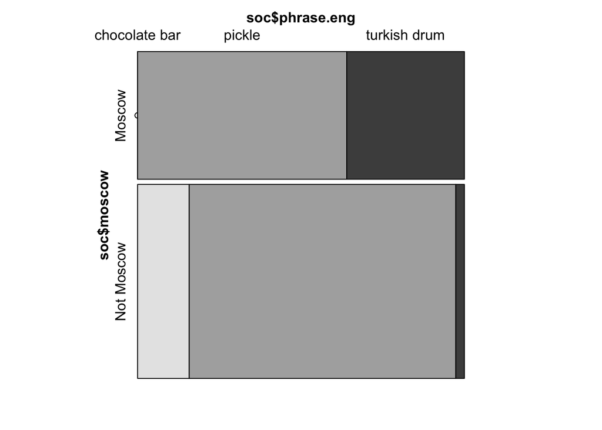

```r
#install.packages("vcd")
library(vcd)
mosaic(soc$phrase.eng ~ soc$moscow)
```

From this graph we can see that in Moscow people use *солёный огурец* (pickle) and *турецкий барабан* (turkish drum) while teasing and people not from Moscow rarely use *турецкий барабан* (turkish drum), but often say phrases with *солёный огурец* (pickle) and *шоколадина* (chocolate bar). Now we will not focus on styling, later we will see how to create a mosaic plot via `ggplot2`, however, let us name axes in a more pretty way:

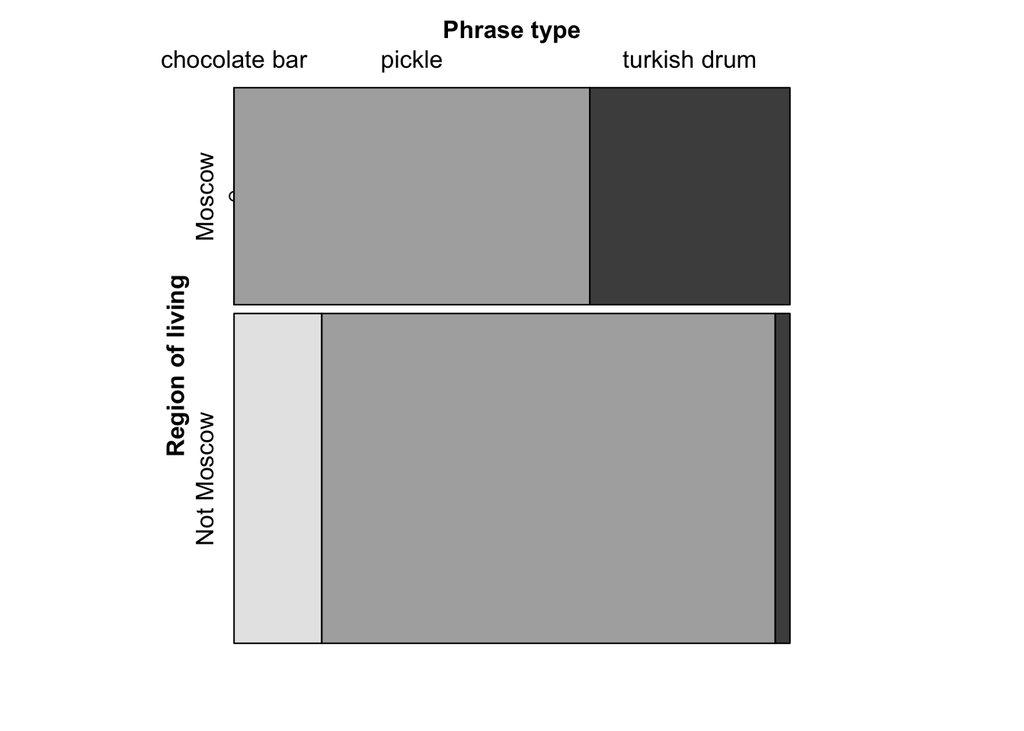

```r
mosaic(data = soc, phrase.eng ~ moscow,
       set_varnames = list(phrase.eng = "Phrase type",
                           moscow = "Region of living"))
```

Пример для таблицы сопряженности 2x2, с пайпами и функцией `mosaicplot`:

```r
soc %>%
  mutate(pickle = ifelse(phrase.eng == "turkish drum", "drum", "not_drum")) %>%
  select(pickle,moscow) %>%
  table() %>%
  chisq.test()
```

```
##
##  Pearson's Chi-squared test with Yates' continuity correction
##
## data:  .
## X-squared = 10.199, df = 1, p-value = 0.001405
```

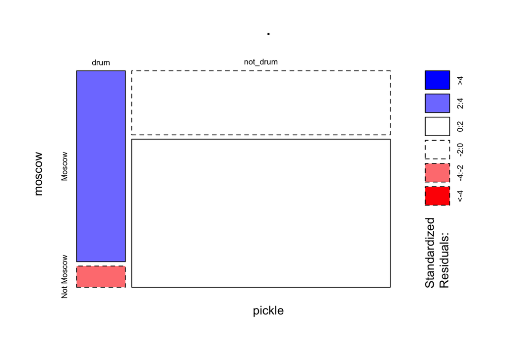

```r
soc %>%
  mutate(pickle = ifelse(phrase.eng == "turkish drum", "drum", "not_drum")) %>%
  select(pickle,moscow) %>%
  table() %>%
  mosaicplot(shade = TRUE)
```

**Упражнение.** См. Поздняков, https://pozdniakov.github.io/tidy_stats/910-tasks.html#sec-chi_sq_tasks Создайте в `heroes` новую колонку `is_human` логического типа, в которой будет TRUE, если супергерой принадлежит расе (Race) “Human”, и FALSE в случае если супергерой принадлежит другой расе. Сравните распределения частот для переменных `is_human` и `Gender`.

Решение:

```r
heroes <- read_csv("https://raw.githubusercontent.com/Pozdniakov/tidy_stats/master/data/heroes_information.csv",
                   na = c("-", "-99"))
heroes %>%
  mutate(is_human = Race == "Human") %>%
  drop_na(is_human, Gender) %>%
  select(is_human, Gender) %>%
  table() %>%
  summary() #  or chisq.test(correct = FALSE)
```

```
## Number of cases in table: 423
## Number of factors: 2
## Test for independence of all factors:
##  Chisq = 0.0003745, df = 1, p-value = 0.9846
```

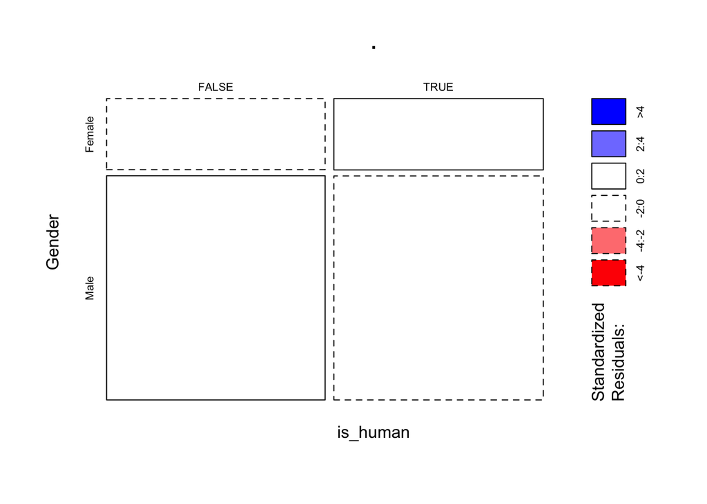

```r
heroes %>%
  mutate(is_human = Race == "Human") %>%
  drop_na(is_human, Gender) %>%
  select(is_human, Gender) %>%
  table() %>%
  mosaicplot(shade = TRUE)
```